# IODS course project

### Description

Illustrate with some nice graphs (library PerformanceAnalysis)

```r
library(PerformanceAnalytics)
```

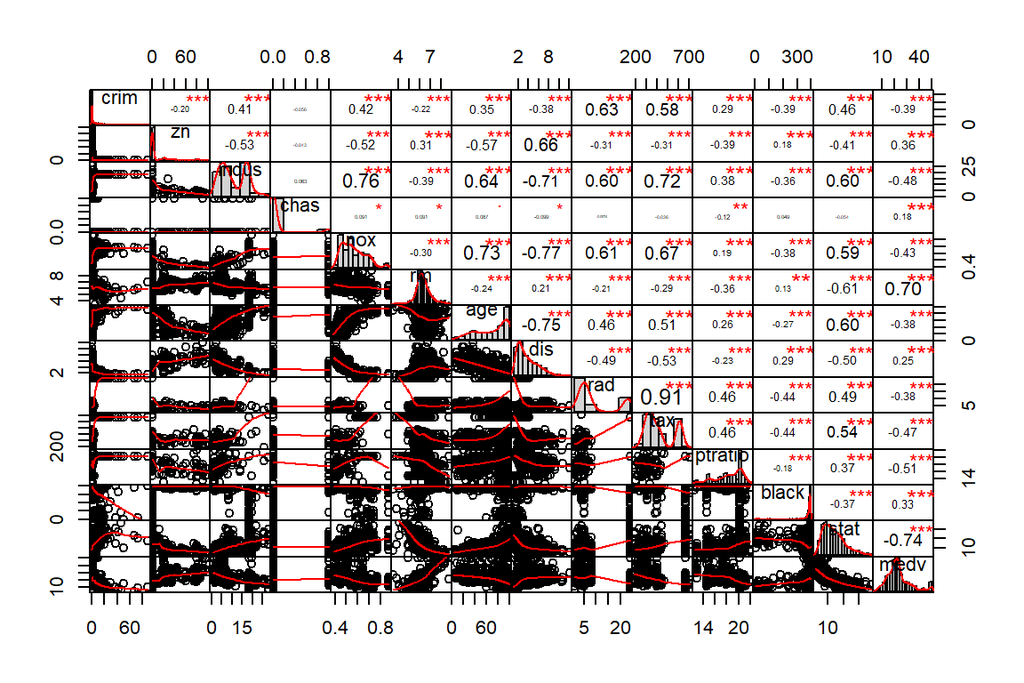

```r
chart.Correlation(Boston)
```

### Data features with some anaysis

#### crim

per capita crime rate by town.

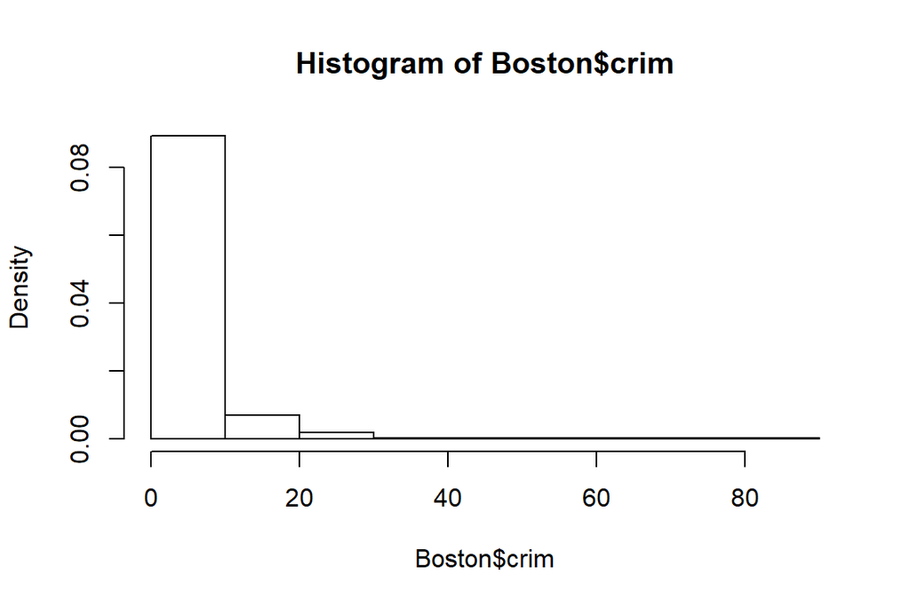

```r
hist(Boston$crim,freq = F)
```

Seems that the crime rate has big variation, highest value, 88.97 suggests that in some region in Boston there really is a huge amount of crimes identified. Still, in most suburbs (89%) the rate stays below 10.

#### zn

proportion of residential land zoned for lots over 25,000 sq.ft.

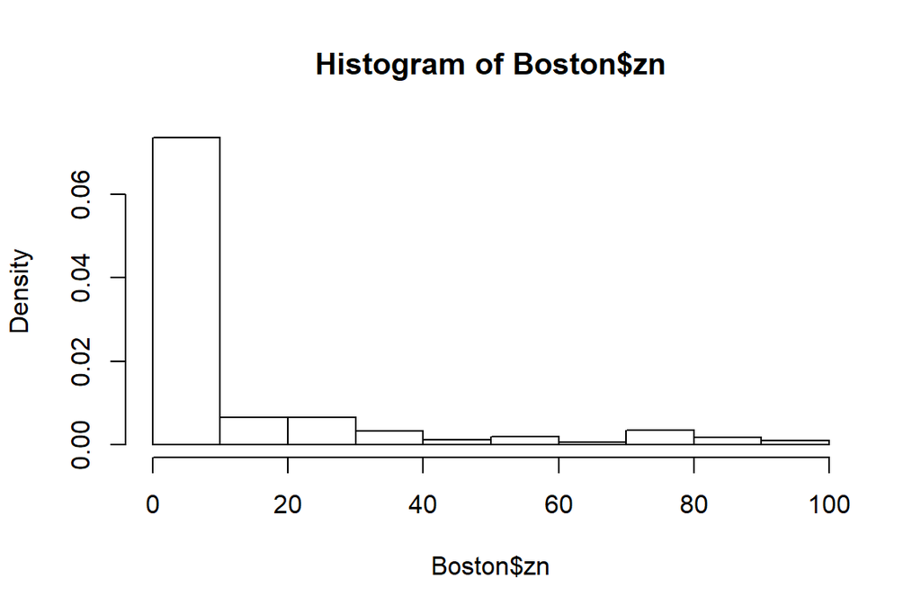

```r
hist(Boston$zn,freq = F)
```

#### indus

proportion of non-retail business acres per town.

This feature varies between 0 and 25, and there seems to be quite a few suburs where the business is solely retail but also some suburbs have more these industrial businesses.

#### chas

Charles River dummy variable (= 1 if tract bounds river; 0 otherwise).

#### nox

nitrogen oxides concentration (parts per 10 million).

#### rm

average number of rooms per dwelling.

Almost like normally distributed variable with average of 6.2.

#### age

proportion of owner-occupied units built prior to 1940.

#### dis

weighted mean of distances to five Boston employment centres.

#### rad

index of accessibility to radial highways.

#### tax

full-value property-tax rate per $10,000.

#### ptratio

pupil-teacher ratio by town.

#### black

1000(Bk - 0.63)^2 where Bk is the proportion of blacks by town.

#### lstat

lower status of the population (percent).

#### medv

median value of owner-occupied homes in $1000s.

### Additional notes of features

Interesting notes about correlation graph: the crime rate seems to be extremely high only in some suburbs that are near to the city center. Also high crime rate happens only in suburbs with higher proportion of old houses (age) These are the same suburbs where also property taxes are high and smaller lots. Apparently this means that in the central areas the crime rates may be high.

In city center the lots are small, taxes higher and also the pollution (nox) level is higher.

The industrial companies locate themselves rather quite close to the city center.

Nitrogen oxid concentration nox is an interesting feature, especially when looked together with outher features. Seems that closer to city center the nox value increases, also correlates the proportion of industrial companies.

In city center, the number of rooms per dwelling can be practically anything, when getting further from the center, the number of rooms has less variance staying closer to the mean value 6.2.

#### Correlation plot

```r
library(corrplot)
library(dplyr)
# calculate the correlation matrix and round it
cor_matrix<-cor(Boston) %>% round(digits=2)

# print the correlation matrix
print(cor_matrix)
```

```
##          crim    zn indus  chas   nox    rm   age   dis   rad   tax
## crim     1.00 -0.20  0.41 -0.06  0.42 -0.22  0.35 -0.38  0.63  0.58
## zn      -0.20  1.00 -0.53 -0.04 -0.52  0.31 -0.57  0.66 -0.31 -0.31
## indus    0.41 -0.53  1.00  0.06  0.76 -0.39  0.64 -0.71  0.60  0.72
## chas    -0.06 -0.04  0.06  1.00  0.09  0.09  0.09 -0.10 -0.01 -0.04
## nox      0.42 -0.52  0.76  0.09  1.00 -0.30  0.73 -0.77  0.61  0.67
## rm      -0.22  0.31 -0.39  0.09 -0.30  1.00 -0.24  0.21 -0.21 -0.29
## age      0.35 -0.57  0.64  0.09  0.73 -0.24  1.00 -0.75  0.46  0.51
## dis     -0.38  0.66 -0.71 -0.10 -0.77  0.21 -0.75  1.00 -0.49 -0.53
## rad      0.63 -0.31  0.60 -0.01  0.61 -0.21  0.46 -0.49  1.00  0.91
## tax      0.58 -0.31  0.72 -0.04  0.67 -0.29  0.51 -0.53  0.91  1.00
## ptratio  0.29 -0.39  0.38 -0.12  0.19 -0.36  0.26 -0.23  0.46  0.46
## black   -0.39  0.18 -0.36  0.05 -0.38  0.13 -0.27  0.29 -0.44 -0.44
## lstat    0.46 -0.41  0.60 -0.05  0.59 -0.61  0.60 -0.50  0.49  0.54
## medv    -0.39  0.36 -0.48  0.18 -0.43  0.70 -0.38  0.25 -0.38 -0.47
##         ptratio black lstat  medv
## crim       0.29 -0.39  0.46 -0.39
## zn        -0.39  0.18 -0.41  0.36
## indus      0.38 -0.36  0.60 -0.48
## chas      -0.12  0.05 -0.05  0.18
## nox        0.19 -0.38  0.59 -0.43
## rm        -0.36  0.13 -0.61  0.70
## age        0.26 -0.27  0.60 -0.38
## dis       -0.23  0.29 -0.50  0.25
## rad        0.46 -0.44  0.49 -0.38
## tax        0.46 -0.44  0.54 -0.47
## ptratio    1.00 -0.18  0.37 -0.51
## black     -0.18  1.00 -0.37  0.33
## lstat      0.37 -0.37  1.00 -0.74
## medv      -0.51  0.33 -0.74  1.00
```

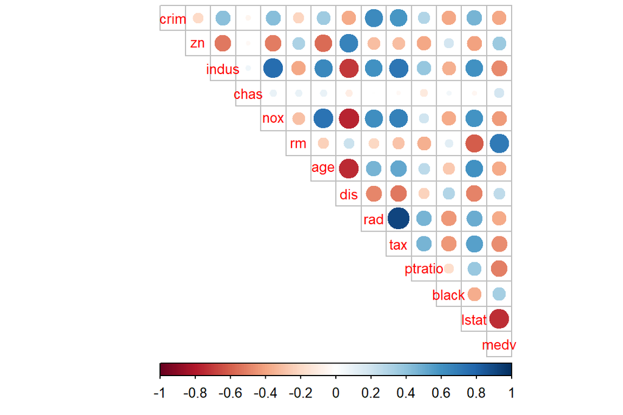

```r
# visualize the correlation matrix
corrplot(cor_matrix, method="circle", type="upper", cl.pos = "b", tl.pos = "d", tl.cex = 0.8)
```

### Scale data

Data standardization scales all explanatory variables such that their mean value and standard deviation are the same. The mean value become zero (0) and the standard deviation becomes one (1). This is required here since we want to apply discriminant analysis, which assumes that variables are normally distributed and that their variance is same.

Scaling & Transfer into a dataframe:

```r
# MASS and Boston dataset are available

# center and standardize variables
boston_scaled <- scale(Boston)

# summaries of the scaled variables
summary(boston_scaled)
```

```
##       crim                 zn               indus
##  Min.   :-0.419367   Min.   :-0.48724   Min.   :-1.5563
##  1st Qu.:-0.410563   1st Qu.:-0.48724   1st Qu.:-0.8668
##  Median :-0.390280   Median :-0.48724   Median :-0.2109
##  Mean   : 0.000000   Mean   : 0.00000   Mean   : 0.0000
##  3rd Qu.: 0.007389   3rd Qu.: 0.04872   3rd Qu.: 1.0150
##  Max.   : 9.924110   Max.   : 3.80047   Max.   : 2.4202
##       chas              nox                rm               age
##  Min.   :-0.2723   Min.   :-1.4644   Min.   :-3.8764   Min.   :-2.3331
##  1st Qu.:-0.2723   1st Qu.:-0.9121   1st Qu.:-0.5681   1st Qu.:-0.8366
##  Median :-0.2723   Median :-0.1441   Median :-0.1084   Median : 0.3171
##  Mean   : 0.0000   Mean   : 0.0000   Mean   : 0.0000   Mean   : 0.0000
##  3rd Qu.:-0.2723   3rd Qu.: 0.5981   3rd Qu.: 0.4823   3rd Qu.: 0.9059
##  Max.   : 3.6648   Max.   : 2.7296   Max.   : 3.5515   Max.   : 1.1164
##       dis               rad               tax             ptratio
##  Min.   :-1.2658   Min.   :-0.9819   Min.   :-1.3127   Min.   :-2.7047
##  1st Qu.:-0.8049   1st Qu.:-0.6373   1st Qu.:-0.7668   1st Qu.:-0.4876
##  Median :-0.2790   Median :-0.5225   Median :-0.4642   Median : 0.2746
##  Mean   : 0.0000   Mean   : 0.0000   Mean   : 0.0000   Mean   : 0.0000
##  3rd Qu.: 0.6617   3rd Qu.: 1.6596   3rd Qu.: 1.5294   3rd Qu.: 0.8058
##  Max.   : 3.9566   Max.   : 1.6596   Max.   : 1.7964   Max.   : 1.6372
##      black             lstat              medv
##  Min.   :-3.9033   Min.   :-1.5296   Min.   :-1.9063
##  1st Qu.: 0.2049   1st Qu.:-0.7986   1st Qu.:-0.5989
##  Median : 0.3808   Median :-0.1811   Median :-0.1449
##  Mean   : 0.0000   Mean   : 0.0000   Mean   : 0.0000
##  3rd Qu.: 0.4332   3rd Qu.: 0.6024   3rd Qu.: 0.2683
##  Max.   : 0.4406   Max.   : 3.5453   Max.   : 2.9865
```

```r
# class of the boston_scaled object
class(boston_scaled)
```

```
## [1] "matrix"
```

```r
# change the object to data frame
boston_scaled <- as.data.frame(boston_scaled)
```

### Crime rate categories

Create a categorical variable of crime rate with four categories: low, med_low, med_high, high

```r
# MASS, Boston and boston_scaled are available
library(dplyr)

# create a quantile vector of crim and print it
bins <- quantile(boston_scaled$crim)
bins
```

```
##           0%          25%          50%          75%         100%
## -0.419366929 -0.410563278 -0.390280295  0.007389247  9.924109610
```

```r
# create a categorical variable 'crime'
crime <- cut(boston_scaled$crim, breaks = bins, include.lowest = TRUE, label = c("low","med_low","med_high", "high"))

# remove original crim from the dataset
boston_scaled <- dplyr::select(boston_scaled, -crim)

# add the new categorical value to scaled data
boston_scaled <- data.frame(boston_scaled, crime)
```

### Create train (80%) and test (20%) data

```r
# boston_scaled is available

# number of rows in the Boston dataset
n <- dim(boston_scaled)[1]

# choose randomly 80% of the rows
ind <- sample(n,  size = n * 0.8)

# create train set
train <- boston_scaled[ind,]

# create test set
test <- boston_scaled[-ind,]
```

### LDA model fit

Fit LDA on the train set. crime rate is the target and all other variables are predictors

```r
# MASS and train are available

# linear discriminant analysis
lda.fit <- lda(crime ~ ., data = train)

# print the lda.fit object
lda.fit
```

```
## Call:
## lda(crime ~ ., data = train)
##
## Prior probabilities of groups:
##       low   med_low  med_high      high
## 0.2475248 0.2326733 0.2475248 0.2722772
##
## Group means:
##                   zn      indus        chas        nox          rm
## low       0.90133588 -0.8955339 -0.15421606 -0.8481017  0.52611243
## med_low  -0.08104774 -0.2721267  0.02085925 -0.5676782 -0.11170444
## med_high -0.40062837  0.2018586  0.23949396  0.4367100  0.04008671
## high     -0.48724019  1.0169558 -0.09336997  1.0597808 -0.36284836
##                 age        dis        rad        tax     ptratio
## low      -0.7945579  0.7178668 -0.6947544 -0.7659865 -0.48478522
## med_low  -0.3132059  0.3168567 -0.5591376 -0.4637082 -0.06643653
## med_high  0.4122049 -0.3895606 -0.4087862 -0.3018157 -0.27092303
## high      0.8090626 -0.8453468  1.6397657  1.5152267  0.78268316
##                black       lstat        medv
## low       0.38718901 -0.77028649  0.60749488
## med_low   0.35103010 -0.09507190  0.02685420
## med_high  0.07222058  0.03886492  0.08635258
## high     -0.76462366  0.85597542 -0.68134955
##
## Coefficients of linear discriminants:
##                 LD1         LD2         LD3
## zn       0.09653525  0.67948269 -0.91471538
## indus    0.03452516 -0.24970499  0.32327840
## chas    -0.09939825 -0.11518365  0.13519604
## nox      0.35568772 -0.82746873 -1.29309771
## rm      -0.11569710 -0.06065895 -0.16584744
## age      0.28369670 -0.25694657 -0.14066565
## dis     -0.01295339 -0.32316551  0.35287413
## rad      3.22909616  0.91758900 -0.27447000
## tax     -0.02953521 -0.01315760  0.79597083
## ptratio  0.11159155  0.00880920 -0.22590033
## black   -0.10796685  0.01988130  0.14053095
## lstat    0.16723856 -0.18951005  0.48919704
## medv     0.15279616 -0.31070257 -0.05412596
##
## Proportion of trace:
##    LD1    LD2    LD3
## 0.9535 0.0334 0.0131
```

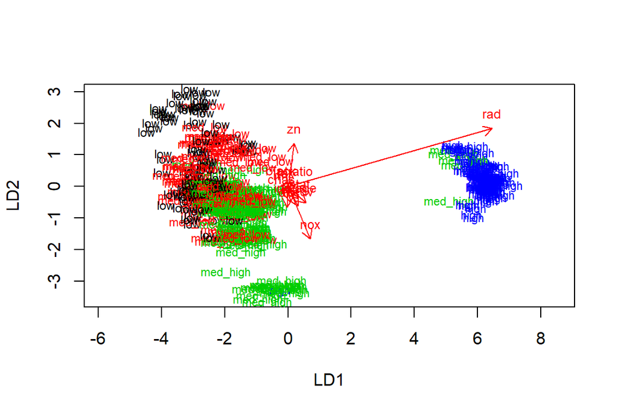

```r
# the function for lda biplot arrows
lda.arrows <- function(x, myscale = 1, arrow_heads = 0.1, color = "red", tex = 0.75, choices = c(1,2)){
  heads <- coef(x)
  arrows(x0 = 0, y0 = 0,
         x1 = myscale * heads[,choices[1]],
         y1 = myscale * heads[,choices[2]], col=color, length = arrow_heads)
  text(myscale * heads[,choices], labels = row.names(heads),
       cex = tex, col=color, pos=3)
}

# target classes as numeric
classes <- as.numeric(train$crime)

# plot the lda results
plot(lda.fit, dimen = 2, col=classes, pch = classes)

lda.arrows(lda.fit, myscale = 2)
```

### Predict test data crime rates

Save the real crime rates of the test data in variable correct_classes and then make prediction

```r
# save the correct classes from test data
correct_classes <- test$crime

# remove the crime variable from test data
test <- dplyr::select(test, -crime)

#predict
# lda.fit, correct_classes and test are available
```

```r
# predict classes with test data
lda.pred <- predict(lda.fit, newdata = test)

# crosstabulate the results
(confusion <- table(correct = correct_classes, predicted = lda.pred$class))
```

```
##           predicted
## correct    low med_low med_high high
##   low       19       8        0    0
##   med_low    4      23        5    0
##   med_high   0       9       16    1
##   high       0       0        0   17
```

### K-means algorithm

To explore the Boston data with k-means algorithm, we need to reload & normalize the data.

```r
data(Boston)
# MASS and Boston dataset are available

# center and standardize variables
boston_scaled2 <- scale(Boston)

# summaries of the scaled variables
summary(boston_scaled2)
```

```
##       crim                 zn               indus
##  Min.   :-0.419367   Min.   :-0.48724   Min.   :-1.5563
##  1st Qu.:-0.410563   1st Qu.:-0.48724   1st Qu.:-0.8668
##  Median :-0.390280   Median :-0.48724   Median :-0.2109
##  Mean   : 0.000000   Mean   : 0.00000   Mean   : 0.0000
##  3rd Qu.: 0.007389   3rd Qu.: 0.04872   3rd Qu.: 1.0150
##  Max.   : 9.924110   Max.   : 3.80047   Max.   : 2.4202
##       chas              nox                rm               age
##  Min.   :-0.2723   Min.   :-1.4644   Min.   :-3.8764   Min.   :-2.3331
##  1st Qu.:-0.2723   1st Qu.:-0.9121   1st Qu.:-0.5681   1st Qu.:-0.8366
##  Median :-0.2723   Median :-0.1441   Median :-0.1084   Median : 0.3171
##  Mean   : 0.0000   Mean   : 0.0000   Mean   : 0.0000   Mean   : 0.0000
##  3rd Qu.:-0.2723   3rd Qu.: 0.5981   3rd Qu.: 0.4823   3rd Qu.: 0.9059
##  Max.   : 3.6648   Max.   : 2.7296   Max.   : 3.5515   Max.   : 1.1164
##       dis               rad               tax             ptratio
##  Min.   :-1.2658   Min.   :-0.9819   Min.   :-1.3127   Min.   :-2.7047
##  1st Qu.:-0.8049   1st Qu.:-0.6373   1st Qu.:-0.7668   1st Qu.:-0.4876
##  Median :-0.2790   Median :-0.5225   Median :-0.4642   Median : 0.2746
##  Mean   : 0.0000   Mean   : 0.0000   Mean   : 0.0000   Mean   : 0.0000
##  3rd Qu.: 0.6617   3rd Qu.: 1.6596   3rd Qu.: 1.5294   3rd Qu.: 0.8058
##  Max.   : 3.9566   Max.   : 1.6596   Max.   : 1.7964   Max.   : 1.6372
##      black             lstat              medv
##  Min.   :-3.9033   Min.   :-1.5296   Min.   :-1.9063
##  1st Qu.: 0.2049   1st Qu.:-0.7986   1st Qu.:-0.5989
##  Median : 0.3808   Median :-0.1811   Median :-0.1449
##  Mean   : 0.0000   Mean   : 0.0000   Mean   : 0.0000
##  3rd Qu.: 0.4332   3rd Qu.: 0.6024   3rd Qu.: 0.2683
##  Max.   : 0.4406   Max.   : 3.5453   Max.   : 2.9865
```

```r
# class of the boston_scaled object
class(boston_scaled2)
```

```
## [1] "matrix"
```

```r
# change the object to data frame
boston_scaled2 <- as.data.frame(boston_scaled2)
```

#### Distances: euclidean

```r
# load MASS and Boston
library(MASS)
data('Boston')

# euclidean distance matrix
dist_eu <- dist(Boston, method = "euclidean")
```

#### Distances: manhattan

```r
# look at the summary of the distances
summary(dist_eu)
```

```
##    Min. 1st Qu.  Median    Mean 3rd Qu.    Max.
##   1.119  85.624 170.539 226.315 371.950 626.047
```

```r
# manhattan distance matrix
dist_man <- dist(Boston, method = "manhattan")

# look at the summary of the distances
summary(dist_man)
```

```
##     Min.  1st Qu.   Median     Mean  3rd Qu.     Max.
##    2.016  149.145  279.505  342.899  509.707 1198.265
```

#### Find optimal number of centers:

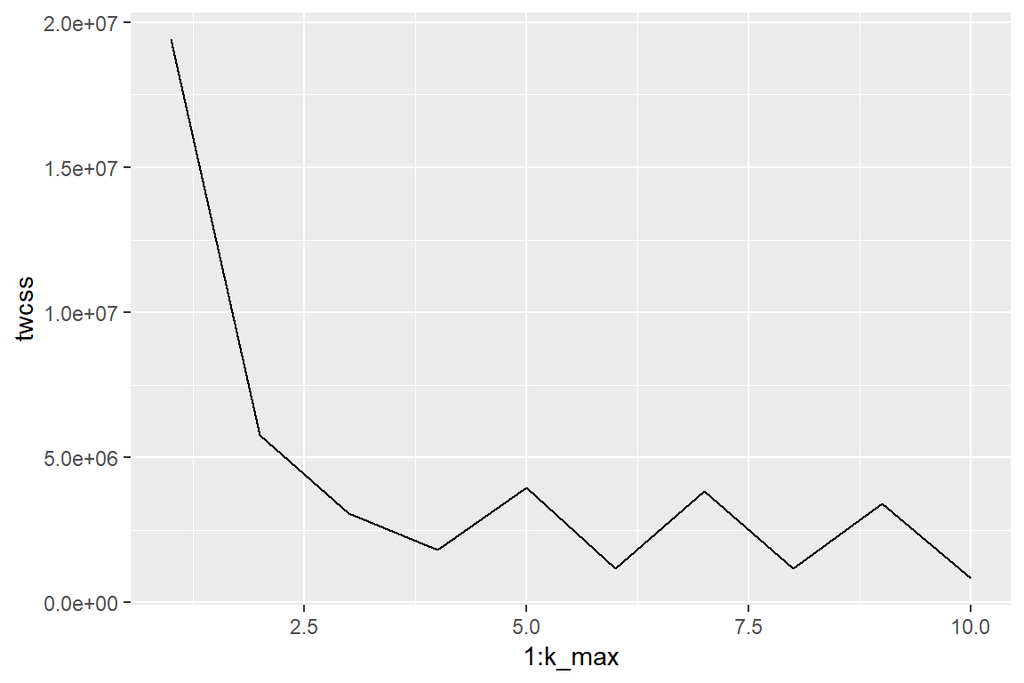

```r
# MASS, ggplot2 and Boston dataset are available
library(ggplot2)
set.seed(123)

# determine the number of clusters
k_max <- 10

# calculate the total within sum of squares
twcss <- sapply(1:k_max, function(k){kmeans(Boston, k)$tot.withinss})

# visualize the results
qplot(x = 1:k_max, y = twcss, geom = 'line')
```

Optimal number of centers seems to be 2 as the function value drops permanently after 2.

[figure not shown]

```r
# k-means clustering
km <-kmeans(Boston, centers = 2)

# plot the Boston dataset with clusters
pairs(Boston, col = km$cluster)
```

The data seems to be well separable in two clusters with many pairs of variables.

### Bonus task. 4 clusters

[figure not shown]

```r
# k-means clustering
kmBonus <-kmeans(Boston, centers = 4)

# plot the Boston dataset with clusters
pairs(Boston, col = kmBonus$cluster)
```

# Week 5 results

## Useful links

### Video

Dimension reduction and PCA:

http://player.vimeo.com/video/204164956

Biplots:

http://player.vimeo.com/video/204165420

MCA:

http://player.vimeo.com/video/204251158

### Slides

The presentation slides related to the videos above are here: https://tuomonieminen.github.io/Helsinki-Open-Data-Science/#/54

### Other links

Some useful links related to this weeks topics:

PCA explained visually http://setosa.io/ev/principal-component-analysis/ Mathematical tutorial on PCA https://arxiv.org/pdf/1404.1100.pdf Biplots in practise (e-book by Michael Greenacre) http://www.multivariatestatistics.org/biplots.html Correspondence analysis - general purpose https://documents.software.dell.com/statistics/textbook/correspondence-analysis#general The FactoMineR webpage http://factominer.free.fr/

## Data analysis

### Data wrangling

Link to data wrangling part (R script) https://github.com/salopant/IODS-project/blob/master/data/human.R

### Data described

The features in the data are

- Country - Country name, id of the row
- Edu2F - Education rate of female
- LabFM - Labour force participation rate of both genders
- LifeEx - Life expectancy at birth, years
- ExpEduYrs - Expected years of schooling
- GNI - Gross national income (GNI) per capita
- MaternMortR - Maternal mortar rate
- AdoBirthR - Births per 1000 women ages 15 - 19
- PctReprParl - Women share of seats in parliament

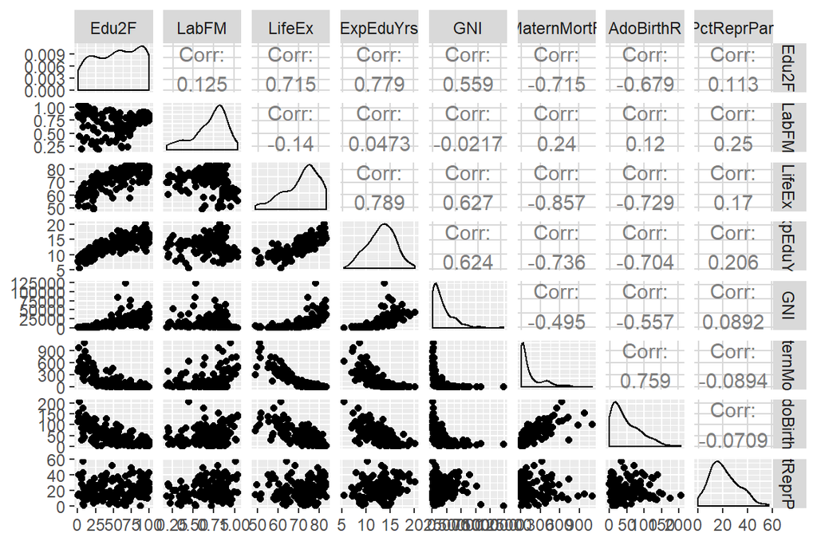

```r
library(dplyr)
library(corrplot)

human <- read.csv("./data/human_mod.csv", row.names = 1)
# Access GGally
library(GGally)

# visualize the 'human_' variables
ggpairs(human)
```

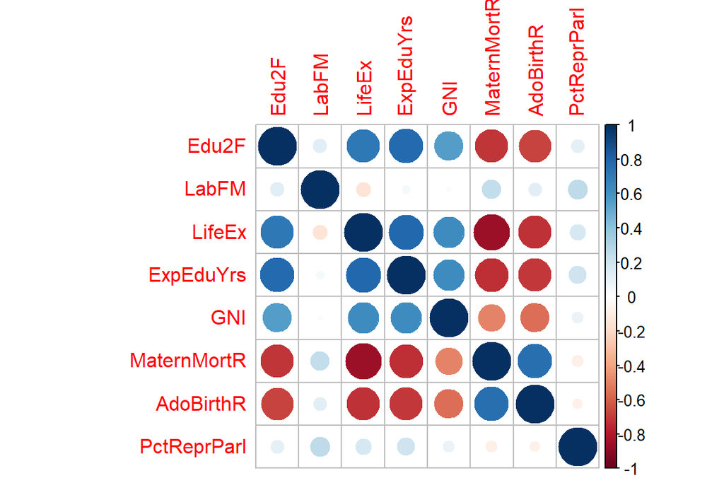

```r
# compute the correlation matrix and visualize it with corrplot
cor(human) %>% corrplot()
```

The correlation plot supports this view. Looks that all other variables are linked to each other except from general labour rate and the female representation in parliament.

### PCA

#### Non scaled data

Next perform principal component analysis on the data:

```r
# modified human is available
library(stats)

# print out summaries of the standardized variables
summary(human)
```

```
##      Edu2F            LabFM            LifeEx        ExpEduYrs
##  Min.   :  0.90   Min.   :0.1857   Min.   :49.00   Min.   : 5.40
##  1st Qu.: 27.15   1st Qu.:0.5984   1st Qu.:66.30   1st Qu.:11.25
##  Median : 56.60   Median :0.7535   Median :74.20   Median :13.50
##  Mean   : 55.37   Mean   :0.7074   Mean   :71.65   Mean   :13.18
##  3rd Qu.: 85.15   3rd Qu.:0.8535   3rd Qu.:77.25   3rd Qu.:15.20
##  Max.   :100.00   Max.   :1.0380   Max.   :83.50   Max.   :20.20
##       GNI          MaternMortR       AdoBirthR       PctReprParl
##  Min.   :   581   Min.   :   1.0   Min.   :  0.60   Min.   : 0.00
##  1st Qu.:  4198   1st Qu.:  11.5   1st Qu.: 12.65   1st Qu.:12.40
##  Median : 12040   Median :  49.0   Median : 33.60   Median :19.30
##  Mean   : 17628   Mean   : 149.1   Mean   : 47.16   Mean   :20.91
##  3rd Qu.: 24512   3rd Qu.: 190.0   3rd Qu.: 71.95   3rd Qu.:27.95
##  Max.   :123124   Max.   :1100.0   Max.   :204.80   Max.   :57.50
```

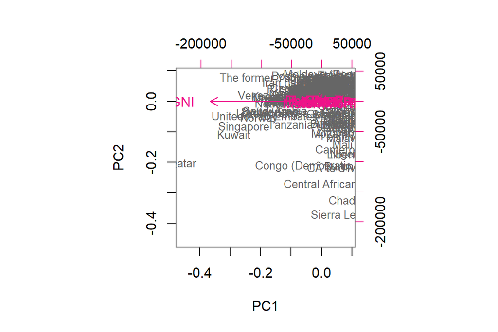

```r
# perform principal component analysis (with the SVD method)
pca_human <- prcomp(human)

# draw a biplot of the principal component representation and the original variables
biplot(pca_human, choices = 1:2, cex = c(0.8, 1), col=c("grey40", "deeppink2"))
```

Now, perform the same PCA on *normalized* data

```r
# modified human is available
library(stats)
# standardize the variables
human_std <- scale(human)

# print out summaries of the standardized variables
summary(human_std)
```

```
##      Edu2F              LabFM             LifeEx          ExpEduYrs
##  Min.   :-1.76122   Min.   :-2.6247   Min.   :-2.7188   Min.   :-2.7378
##  1st Qu.:-0.91250   1st Qu.:-0.5484   1st Qu.:-0.6425   1st Qu.:-0.6782
##  Median : 0.03967   Median : 0.2316   Median : 0.3056   Median : 0.1140
##  Mean   : 0.00000   Mean   : 0.0000   Mean   : 0.0000   Mean   : 0.0000
##  3rd Qu.: 0.96275   3rd Qu.: 0.7350   3rd Qu.: 0.6717   3rd Qu.: 0.7126
##  Max.   : 1.44288   Max.   : 1.6632   Max.   : 1.4218   Max.   : 2.4730
##       GNI           MaternMortR        AdoBirthR        PctReprParl
##  Min.   :-0.9193   Min.   :-0.6992   Min.   :-1.1325   Min.   :-1.8203
##  1st Qu.:-0.7243   1st Qu.:-0.6496   1st Qu.:-0.8394   1st Qu.:-0.7409
##  Median :-0.3013   Median :-0.4726   Median :-0.3298   Median :-0.1403
##  Mean   : 0.0000   Mean   : 0.0000   Mean   : 0.0000   Mean   : 0.0000
##  3rd Qu.: 0.3712   3rd Qu.: 0.1932   3rd Qu.: 0.6030   3rd Qu.: 0.6127
##  Max.   : 5.6890   Max.   : 4.4899   Max.   : 3.8344   Max.   : 3.1850
```

[figure not shown]

```r
# perform principal component analysis (with the SVD method)
pca_human_std <- prcomp(human_std)

# get the variances explained
s <- pca_human_std$sdev
pca_pr <- round(100*s, digits = 1)
# create object pc_lab to be used as axis labels
pc_lab <- paste0(names(pca_pr), " (", pca_pr, "%)")


# draw a biplot of the principal component representation and the original variables
biplot(pca_human_std, choices = 1:2, cex = c(0.8, 1), col = c("grey40", "deeppink2"), xlab = pc_lab[1], ylab = pc_lab[2])

text(-7,10,"Nordic countries",col = "red")
text(3,-10,"Middle East countries",col = "red")
text(7,6.5,"African countries",col = "red")
```

Now the biplot of the analysis shows that really all other variables than LabFM and PctReprParl are closely aligned in direction of the first principal component implying that they do correlate and that they also explain most of the variance in the data. On the other hand the two named variables are almost parallel with the second PC. This figure makes a lot of sense when interpreted with the correlation plot.

I can also recognize some clusters in the country data. The nordic countries seem to b epositioned pretty close to each other in the upper left corner suggesting that they are somewhat similar. A cluster of middle east countries can also be identified in the lower half of the plot and a group of African countries seem to be the only ones that stay in the upper right corner.

### Multiple Correspondence Analysis

Perform the MCA on the data tea of dataset found in package “FactoMineR”

```r
# the tea dataset and packages FactoMineR, ggplot2, dplyr and tidyr are available
library(dplyr)
library(ggplot2)
library(tidyr)
library(FactoMineR)
data(tea)

summary(tea)
```

```
##          breakfast           tea.time          evening          lunch
##  breakfast    :144   Not.tea time:131   evening    :103   lunch    : 44
##  Not.breakfast:156   tea time    :169   Not.evening:197   Not.lunch:256
##
##
##
##
##
##         dinner           always          home           work
##  dinner    : 21   always    :103   home    :291   Not.work:213
##  Not.dinner:279   Not.always:197   Not.home:  9   work    : 87
##
##
##
##
##
##         tearoom           friends          resto          pub
##  Not.tearoom:242   friends    :196   Not.resto:221   Not.pub:237
##  tearoom    : 58   Not.friends:104   resto    : 79   pub    : 63
##
##
##
##
##
##         Tea         How           sugar                     how
##  black    : 74   alone:195   No.sugar:155   tea bag           :170
##  Earl Grey:193   lemon: 33   sugar   :145   tea bag+unpackaged: 94
##  green    : 33   milk : 63                  unpackaged        : 36
##                  other:  9
##
##
##
##                   where                 price          age        sex
##  chain store         :192   p_branded      : 95   Min.   :15.00   F:178
##  chain store+tea shop: 78   p_cheap        :  7   1st Qu.:23.00   M:122
##  tea shop            : 30   p_private label: 21   Median :32.00
##                             p_unknown      : 12   Mean   :37.05
##                             p_upscale      : 53   3rd Qu.:48.00
##                             p_variable     :112   Max.   :90.00
##
```

[output cut: 25 more lines]

```
##  feminine    :129   Not.sophisticated: 85   No.slimming:255
##  Not.feminine:171   sophisticated    :215   slimming   : 45
##
##
##
##
##
##         exciting          relaxing              effect.on.health
##  exciting   :116   No.relaxing:113   effect on health   : 66
##  No.exciting:184   relaxing   :187   No.effect on health:234
##
##
##
##
##
```

```r
str(tea)
```

```
## 'data.frame':    300 obs. of  36 variables:
##  $ breakfast       : Factor w/ 2 levels "breakfast","Not.breakfast": 1 1 2 2 1 2 1 2 1 1 ...
##  $ tea.time        : Factor w/ 2 levels "Not.tea time",..: 1 1 2 1 1 1 2 2 2 1 ...
##  $ evening         : Factor w/ 2 levels "evening","Not.evening": 2 2 1 2 1 2 2 1 2 1 ...
##  $ lunch           : Factor w/ 2 levels "lunch","Not.lunch": 2 2 2 2 2 2 2 2 2 2 ...
##  $ dinner          : Factor w/ 2 levels "dinner","Not.dinner": 2 2 1 1 2 1 2 2 2 2 ...
##  $ always          : Factor w/ 2 levels "always","Not.always": 2 2 2 2 1 2 2 2 2 2 ...
##  $ home            : Factor w/ 2 levels "home","Not.home": 1 1 1 1 1 1 1 1 1 1 ...
##  $ work            : Factor w/ 2 levels "Not.work","work": 1 1 2 1 1 1 1 1 1 1 ...
##  $ tearoom         : Factor w/ 2 levels "Not.tearoom",..: 1 1 1 1 1 1 1 1 1 2 ...
##  $ friends         : Factor w/ 2 levels "friends","Not.friends": 2 2 1 2 2 2 1 2 2 2 ...
##  $ resto           : Factor w/ 2 levels "Not.resto","resto": 1 1 2 1 1 1 1 1 1 1 ...
##  $ pub             : Factor w/ 2 levels "Not.pub","pub": 1 1 1 1 1 1 1 1 1 1 ...
##  $ Tea             : Factor w/ 3 levels "black","Earl Grey",..: 1 1 2 2 2 2 2 1 2 1 ...
##  $ How             : Factor w/ 4 levels "alone","lemon",..: 1 3 1 1 1 1 1 3 3 1 ...
```

[output cut: 22 more lines]

The data obviously contains personal opinions collected from 300 persons regarding their habits/preferences/experiences about enjoying tea.

From the 36 variables, I run the study on 6 selected variables named as

- “Tea” - tea quality name
- “How” - what prefer to add in tea, levels: alone, lemon, milk, other
- “how” - how the tea should be packed (tea bag, unpackaged)
- “sugar” - to add sugar or no
- “where” - where to buy tea
- “lunch” - enjoy tea on lunch or not?

```r
# column names to keep in the dataset
keep_columns <- c("Tea", "How", "how", "sugar", "where", "lunch")
# select the 'keep_columns' to create a new dataset
tea_time <- dplyr::select(tea, one_of(keep_columns))

# look at the summaries and structure of the data
summary(tea_time)
```

```
##         Tea         How                      how           sugar
##  black    : 74   alone:195   tea bag           :170   No.sugar:155
##  Earl Grey:193   lemon: 33   tea bag+unpackaged: 94   sugar   :145
##  green    : 33   milk : 63   unpackaged        : 36
##                  other:  9
##                   where           lunch
##  chain store         :192   lunch    : 44
##  chain store+tea shop: 78   Not.lunch:256
##  tea shop            : 30
##
```

```r
str(tea_time)
```

```
## 'data.frame':    300 obs. of  6 variables:
##  $ Tea  : Factor w/ 3 levels "black","Earl Grey",..: 1 1 2 2 2 2 2 1 2 1 ...
##  $ How  : Factor w/ 4 levels "alone","lemon",..: 1 3 1 1 1 1 1 3 3 1 ...
##  $ how  : Factor w/ 3 levels "tea bag","tea bag+unpackaged",..: 1 1 1 1 1 1 1 1 2 2 ...
##  $ sugar: Factor w/ 2 levels "No.sugar","sugar": 2 1 1 2 1 1 1 1 1 1 ...
##  $ where: Factor w/ 3 levels "chain store",..: 1 1 1 1 1 1 1 1 2 2 ...
##  $ lunch: Factor w/ 2 levels "lunch","Not.lunch": 2 2 2 2 2 2 2 2 2 2 ...
```

MCA modeling

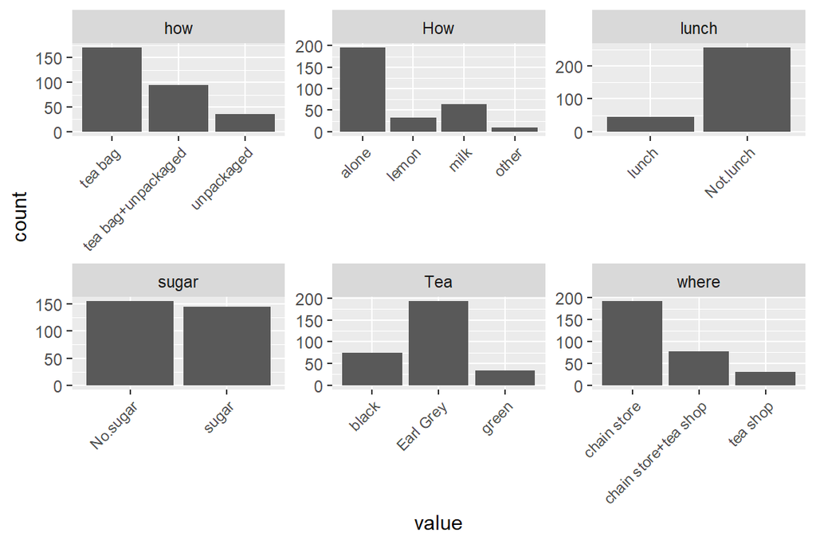

```r
# visualize the dataset
gather(tea_time) %>% ggplot(aes(value)) + facet_wrap("key", scales = "free") + geom_bar() + theme(axis.text.x = element_text(angle = 45, hjust = 1, size = 8))
```

```r
# multiple correspondence analysis
mca <- MCA(tea_time, graph = FALSE)

# summary of the model
summary(mca)
```

```
##
## Call:
## MCA(X = tea_time, graph = FALSE)
##
##
## Eigenvalues
##                        Dim.1   Dim.2   Dim.3   Dim.4   Dim.5   Dim.6
## Variance               0.279   0.261   0.219   0.189   0.177   0.156
## % of var.             15.238  14.232  11.964  10.333   9.667   8.519
## Cumulative % of var.  15.238  29.471  41.435  51.768  61.434  69.953
##                        Dim.7   Dim.8   Dim.9  Dim.10  Dim.11
## Variance               0.144   0.141   0.117   0.087   0.062
## % of var.              7.841   7.705   6.392   4.724   3.385
## Cumulative % of var.  77.794  85.500  91.891  96.615 100.000
##
## Individuals (the 10 first)
##                       Dim.1    ctr   cos2    Dim.2    ctr   cos2    Dim.3
## 1                  | -0.298  0.106  0.086 | -0.328  0.137  0.105 | -0.327
## 2                  | -0.237  0.067  0.036 | -0.136  0.024  0.012 | -0.695
## 3                  | -0.369  0.162  0.231 | -0.300  0.115  0.153 | -0.202
## 4                  | -0.530  0.335  0.460 | -0.318  0.129  0.166 |  0.211
## 5                  | -0.369  0.162  0.231 | -0.300  0.115  0.153 | -0.202
## 6                  | -0.369  0.162  0.231 | -0.300  0.115  0.153 | -0.202
## 7                  | -0.369  0.162  0.231 | -0.300  0.115  0.153 | -0.202
## 8                  | -0.237  0.067  0.036 | -0.136  0.024  0.012 | -0.695
## 9                  |  0.143  0.024  0.012 |  0.871  0.969  0.435 | -0.067
## 10                 |  0.476  0.271  0.140 |  0.687  0.604  0.291 | -0.650
##                       ctr   cos2
## 1                   0.163  0.104 |
## 2                   0.735  0.314 |
## 3                   0.062  0.069 |
## 4                   0.068  0.073 |
## 5                   0.062  0.069 |
## 6                   0.062  0.069 |
## 7                   0.062  0.069 |
## 8                   0.735  0.314 |
## 9                   0.007  0.003 |
## 10                  0.643  0.261 |
##
## Categories (the 10 first)
```

[output cut: 16 more lines]

```
## lemon                0.035   3.226 |   1.329  14.771   0.218   8.081 |
## milk                 0.020   2.422 |   0.013   0.003   0.000   0.116 |
## other                0.102   5.534 |  -2.524  14.526   0.197  -7.676 |
## tea bag              0.161  -6.941 |  -0.065   0.183   0.006  -1.287 |
## tea bag+unpackaged   0.478  11.956 |   0.019   0.009   0.000   0.226 |
## unpackaged           0.141  -6.482 |   0.257   0.602   0.009   1.640 |
##
## Categorical variables (eta2)
##                      Dim.1 Dim.2 Dim.3
## Tea                | 0.126 0.108 0.410 |
## How                | 0.076 0.190 0.394 |
## how                | 0.708 0.522 0.010 |
## sugar              | 0.065 0.001 0.336 |
## where              | 0.702 0.681 0.055 |
## lunch              | 0.000 0.064 0.111 |
```

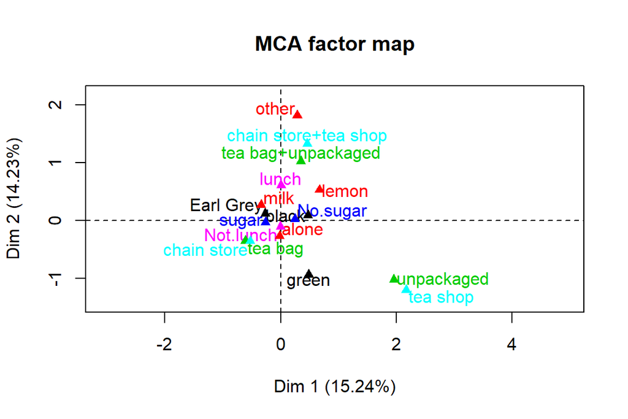

```r
# visualize MCA
plot(mca, invisible=c("ind"), habillage = "quali")
```

The MCA factor map implies that people that enjoy their tea as is (alone) tend to prefer not drinking tea with their lunch. Also people the prefer tea bags buy their tea from chain store and people who like unpackaged tea prefer shopping in a tea shop and further, people that like both, also do shopping in both kinds of shops.

# Week 6 results

## Useful links

### Other sources

- MABS Book chapter ~ https://www.crcpress.com/Multivariate-Analysis-for-the-Behavioral-Sciences-Second-Edition/Vehkalahti-Everitt/p/book/9780815385158

### Data

https://raw.githubusercontent.com/KimmoVehkalahti/MABS/master/Examples/data/BPRS.txt

https://raw.githubusercontent.com/KimmoVehkalahti/MABS/master/Examples/data/rats.txt

## Task 1: Implement the analyses of Chapter 8 of MABS using the RATS data

### Load data

```r
RATS = read.csv("./ratsl.csv")
str(RATS)
```

```
## 'data.frame':    176 obs. of  5 variables:
##  $ ID   : int  1 2 3 4 5 6 7 8 9 10 ...
##  $ Group: int  1 1 1 1 1 1 1 1 2 2 ...
##  $ wds  : Factor w/ 11 levels "WD1","WD15","WD22",..: 1 1 1 1 1 1 1 1 1 1 ...
##  $ rats : int  240 225 245 260 255 260 275 245 410 405 ...
##  $ wd   : int  1 1 1 1 1 1 1 1 1 1 ...
```

```r
RATS$Group = factor(RATS$Group)
RATS$ID = factor(RATS$ID)
```

### Scale data

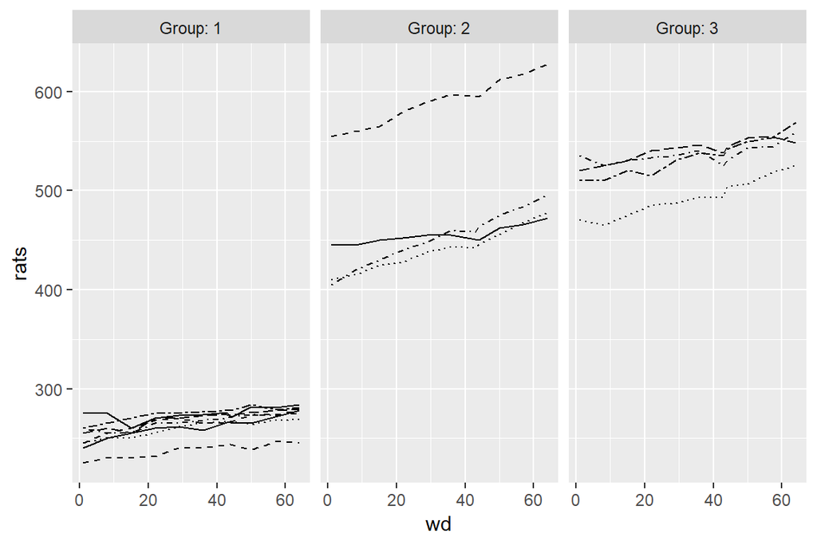

```r
#Access the package ggplot2
library(ggplot2)

# Draw the plot
ggplot(RATS, aes(x = wd, y = rats, linetype = ID)) +
  geom_line() +
  scale_linetype_manual(values = rep(1:10, times=4)) +
  facet_grid(. ~ Group, labeller = label_both) +
  theme(legend.position = "none") +
  scale_y_continuous(limits = c(min(RATS$rats), max(RATS$rats)))
```

```r
# Standardise the variable bprs
RATS <- RATS %>%
  group_by(wd) %>%
  mutate(stdrats = (rats - mean(rats))/sd(rats) ) %>%
  ungroup()

# Glimpse the data
glimpse(RATS)
```

```
## Observations: 176
## Variables: 6
## $ ID      <fct> 1, 2, 3, 4, 5, 6, 7, 8, 9, 10, 11, 12, 13, 14, 15, 16,...
## $ Group   <fct> 1, 1, 1, 1, 1, 1, 1, 1, 2, 2, 2, 2, 3, 3, 3, 3, 1, 1, ...
## $ wds     <fct> WD1, WD1, WD1, WD1, WD1, WD1, WD1, WD1, WD1, WD1, WD1,...
## $ rats    <int> 240, 225, 245, 260, 255, 260, 275, 245, 410, 405, 445,...
## $ wd      <int> 1, 1, 1, 1, 1, 1, 1, 1, 1, 1, 1, 1, 1, 1, 1, 1, 8, 8, ...
## $ stdrats <dbl> -1.0011429, -1.1203857, -0.9613953, -0.8421525, -0.881...
```

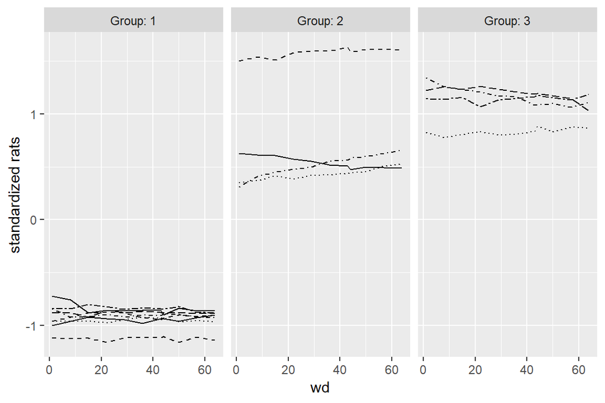

```r
# Plot again with the standardised rats
ggplot(RATS, aes(x = wd, y = stdrats, linetype = ID)) +
  geom_line() +
  scale_linetype_manual(values = rep(1:10, times=4)) +
  facet_grid(. ~ Group, labeller = label_both) +
  theme(legend.position = "none") +
  scale_y_continuous(name = "standardized rats", limits = c(min(RATS$stdrats), max(RATS$stdrats)))
```

### Summarize data

```r
# Number of wd, baseline (wd1) included
n <- RATS$wd %>% unique() %>% length()

# Summary data with mean and standard error of bprs by treatment and week
RATSS <- RATS %>%
  group_by(Group, wd) %>%
  summarise( mean = mean(rats), se = sd(rats)/sqrt(n)) %>%
               ungroup()

# Glimpse the data
glimpse(RATSS)
```

```
## Observations: 33
## Variables: 4
## $ Group <fct> 1, 1, 1, 1, 1, 1, 1, 1, 1, 1, 1, 2, 2, 2, 2, 2, 2, 2, 2,...
## $ wd    <int> 1, 8, 15, 22, 29, 36, 43, 44, 50, 57, 64, 1, 8, 15, 22, ...
## $ mean  <dbl> 250.625, 255.000, 254.375, 261.875, 264.625, 265.000, 26...
## $ se    <dbl> 4.589478, 3.947710, 3.460116, 4.100800, 3.333956, 3.5529...
```

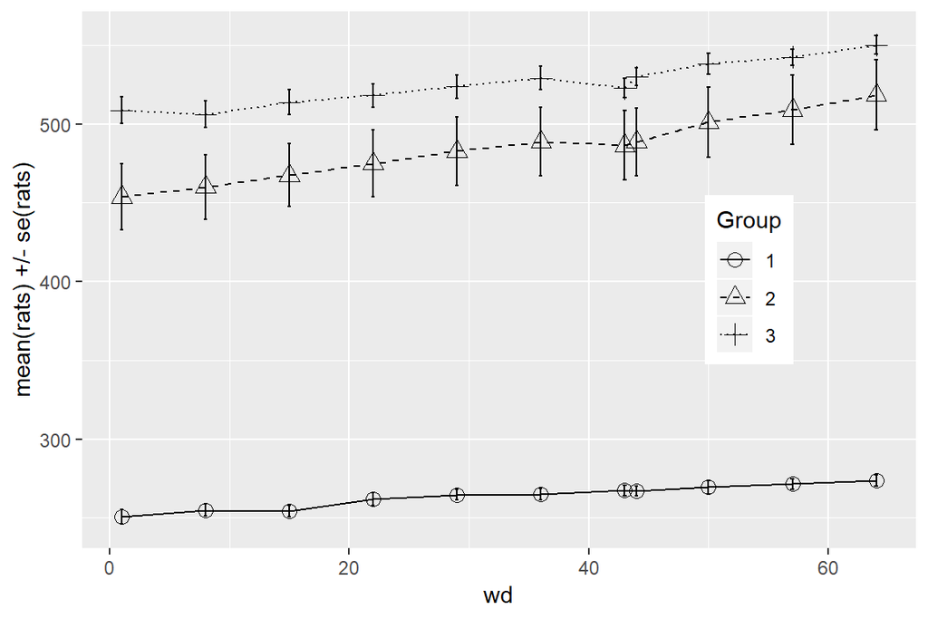

```r
# Plot the mean profiles
ggplot(RATSS, aes(x = wd, y = mean, linetype = Group, shape = Group)) +
 geom_line() +
 scale_linetype_manual(values = c(1,2,3)) +
 geom_point(size=3) +
 scale_shape_manual(values = c(1,2,3)) +
 geom_errorbar(aes(ymin=mean-se, ymax=mean+se, linetype="1"), width=0.3) +
 theme(legend.position = c(0.8,0.5)) +
 scale_y_continuous(name = "mean(rats) +/- se(rats)")
```

### Pick data without the first week

```r
RATS8S <- RATS %>%
  filter(wd > 1) %>%
  group_by(Group, ID) %>%
  summarise( mean=mean(rats) ) %>%
  ungroup()

# Glimpse the data
glimpse(RATS8S)
```

```
## Observations: 16
## Variables: 3
## $ Group <fct> 1, 1, 1, 1, 1, 1, 1, 1, 2, 2, 2, 2, 3, 3, 3, 3
## $ ID    <fct> 1, 2, 3, 4, 5, 6, 7, 8, 9, 10, 11, 12, 13, 14, 15, 16
## $ mean  <dbl> 263.2, 238.9, 261.7, 267.2, 270.9, 276.2, 274.6, 267.5, ...
```

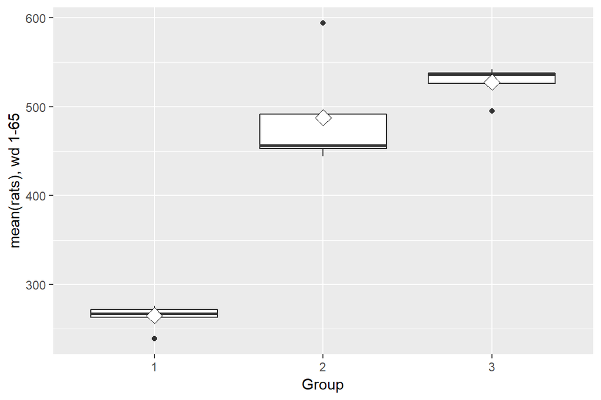

```r
# Draw a boxplot of the mean versus treatment
ggplot(RATS8S, aes(x = Group, y = mean)) +
  geom_boxplot() +
  stat_summary(fun.y = "mean", geom = "point", shape=23, size=4, fill = "white") +
  scale_y_continuous(name = "mean(rats), wd 1-65")
```

### Filter out outliers

```r
# Create a new data by filtering the outlier and adjust the ggplot code the draw the plot again with the new data
RATS8S1 <- RATS %>%
  filter((wd > 1)&((rats > 250 & rats < 550))) %>%
  group_by(Group, ID) %>%
  summarise( mean=mean(rats) ) %>%
  ungroup()

# Glimpse the data
glimpse(RATS8S1)
```

```
## Observations: 14
## Variables: 3
## $ Group <fct> 1, 1, 1, 1, 1, 1, 1, 2, 2, 2, 3, 3, 3, 3
## $ ID    <fct> 1, 3, 4, 5, 6, 7, 8, 9, 10, 11, 13, 14, 15, 16
## $ mean  <dbl> 264.6667, 264.6250, 267.2000, 270.9000, 276.2000, 274.60...
```

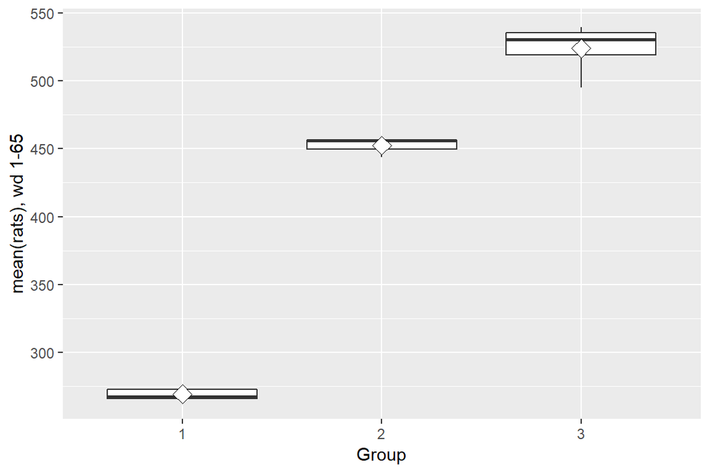

```r
# Draw a boxplot of the mean versus treatment
ggplot(RATS8S1, aes(x = Group, y = mean)) +
  geom_boxplot() +
  stat_summary(fun.y = "mean", geom = "point", shape=23, size=4, fill = "white") +
  scale_y_continuous(name = "mean(rats), wd 1-65")
```

### Anova

```r
ratsOrig <- read.table("https://raw.githubusercontent.com/KimmoVehkalahti/MABS/master/Examples/data/rats.txt", sep  ="\t", header = T)
str(ratsOrig)
```

```
## 'data.frame':    16 obs. of  13 variables:
##  $ ID   : int  1 2 3 4 5 6 7 8 9 10 ...
##  $ Group: int  1 1 1 1 1 1 1 1 2 2 ...
##  $ WD1  : int  240 225 245 260 255 260 275 245 410 405 ...
##  $ WD8  : int  250 230 250 255 260 265 275 255 415 420 ...
##  $ WD15 : int  255 230 250 255 255 270 260 260 425 430 ...
##  $ WD22 : int  260 232 255 265 270 275 270 268 428 440 ...
##  $ WD29 : int  262 240 262 265 270 275 273 270 438 448 ...
##  $ WD36 : int  258 240 265 268 273 277 274 265 443 460 ...
##  $ WD43 : int  266 243 267 270 274 278 276 265 442 458 ...
##  $ WD44 : int  266 244 267 272 273 278 271 267 446 464 ...
##  $ WD50 : int  265 238 264 274 276 284 282 273 456 475 ...
##  $ WD57 : int  272 247 268 273 278 279 281 274 468 484 ...
##  $ WD64 : int  278 245 269 275 280 281 284 278 478 496 ...
```

```r
# Perform a two-sample t-test
#t.test(mean ~ Group, data = RATS8S1, var.equal = TRUE)

# Add the baseline from the original data as a new variable to the summary data
RATS8S2 <- RATS8S %>%
  mutate(baseline = ratsOrig$WD1)

# Fit the linear model with the mean as the response
fit <- lm(mean ~ baseline + Group, data = RATS8S2)

# Compute the analysis of variance table for the fitted model with anova()
anova(fit)
```

```
## Analysis of Variance Table
##
## Response: mean
##           Df Sum Sq Mean Sq   F value   Pr(>F)
## baseline   1 253625  253625 1859.8201 1.57e-14 ***
## Group      2    879     439    3.2219  0.07586 .
## Residuals 12   1636     136
## ---
## Signif. codes:  0 '***' 0.001 '**' 0.01 '*' 0.05 '.' 0.1 ' ' 1
```

### Conclusions

The Anova results imply that the is not enough evidence that the different groups would develop differently in the treatment when the baseline is cancelled from the observation results, but on risk level 10% it would be so.

## Task 2

### Load data (already in long format)

```r
BPRSL = read.csv("./bprsl.csv")
str(BPRSL)
```

```
## 'data.frame':    360 obs. of  5 variables:
##  $ treatment: int  1 1 1 1 1 1 1 1 1 1 ...
##  $ subject  : int  1 2 3 4 5 6 7 8 9 10 ...
##  $ weeks    : Factor w/ 9 levels "week0","week1",..: 1 1 1 1 1 1 1 1 1 1 ...
##  $ bprs     : int  42 58 54 55 72 48 71 30 41 57 ...
##  $ week     : int  0 0 0 0 0 0 0 0 0 0 ...
```

```r
BPRSL$treatment = factor(BPRSL$treatment)
BPRSL$subject = factor(BPRSL$subject)

# Glimpse the data

glimpse(BPRSL)
```

```
## Observations: 360
## Variables: 5
## $ treatment <fct> 1, 1, 1, 1, 1, 1, 1, 1, 1, 1, 1, 1, 1, 1, 1, 1, 1, 1...
## $ subject   <fct> 1, 2, 3, 4, 5, 6, 7, 8, 9, 10, 11, 12, 13, 14, 15, 1...
## $ weeks     <fct> week0, week0, week0, week0, week0, week0, week0, wee...
## $ bprs      <int> 42, 58, 54, 55, 72, 48, 71, 30, 41, 57, 30, 55, 36, ...
## $ week      <int> 0, 0, 0, 0, 0, 0, 0, 0, 0, 0, 0, 0, 0, 0, 0, 0, 0, 0...
```

### Data plot

```r
# Check the dimensions of the data
dim(BPRSL)
```

```
## [1] 360   5
```

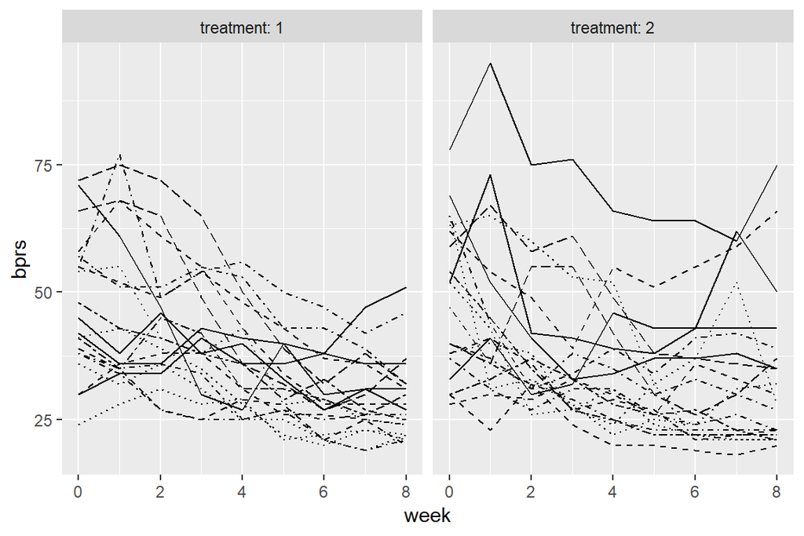

```r
# Plot the data
ggplot(BPRSL, aes(x = week, y = bprs, linetype = subject)) +
  geom_line() +
  scale_linetype_manual(values = rep(1:10, times=4)) +
  facet_grid(. ~ treatment, labeller = label_both) +
  theme(legend.position = "none") +
  scale_y_continuous(limits = c(min(BPRSL$bprs), max(BPRSL$bprs)))
```

### Regression model

```r
# create a regression model
BPRS_reg <- lm(bprs ~ treatment + week, data = BPRSL)
# print out a summary of the model
summary(BPRS_reg)
```

```
##
## Call:
## lm(formula = bprs ~ treatment + week, data = BPRSL)
##
## Residuals:
##     Min      1Q  Median      3Q     Max
## -22.454  -8.965  -3.196   7.002  50.244
##
## Coefficients:
##             Estimate Std. Error t value Pr(>|t|)
## (Intercept)  46.4539     1.3670  33.982   <2e-16 ***
## treatment2    0.5722     1.3034   0.439    0.661
## week         -2.2704     0.2524  -8.995   <2e-16 ***
## ---
## Signif. codes:  0 '***' 0.001 '**' 0.01 '*' 0.05 '.' 0.1 ' ' 1
##
## Residual standard error: 12.37 on 357 degrees of freedom
## Multiple R-squared:  0.1851, Adjusted R-squared:  0.1806
## F-statistic: 40.55 on 2 and 357 DF,  p-value: < 2.2e-16
```

### Random intercept model

```r
# access library lme4
library(lme4)
# Create a random intercept model
BPRS_ref <- lmer(bprs ~ week + treatment + (1 | subject), data = BPRSL, REML = FALSE)

# Print the summary of the model
summary(BPRS_ref)
```

```
## Linear mixed model fit by maximum likelihood  ['lmerMod']
## Formula: bprs ~ week + treatment + (1 | subject)
##    Data: BPRSL
##
##      AIC      BIC   logLik deviance df.resid
##   2748.7   2768.1  -1369.4   2738.7      355
##
## Scaled residuals:
##     Min      1Q  Median      3Q     Max
## -3.0481 -0.6749 -0.1361  0.4813  3.4855
##
## Random effects:
##  Groups   Name        Variance Std.Dev.
##  subject  (Intercept)  47.41    6.885
##  Residual             104.21   10.208
## Number of obs: 360, groups:  subject, 20
##
## Fixed effects:
##             Estimate Std. Error t value
## (Intercept)  46.4539     1.9090  24.334
## week         -2.2704     0.2084 -10.896
## treatment2    0.5722     1.0761   0.532
##
## Correlation of Fixed Effects:
##            (Intr) week
## week       -0.437
## treatment2 -0.282  0.000
```

Note: Pay attention to variability (standard deviation) of the subject

### Random intercept and random slope model

```r
# create a random intercept and random slope model
BPRS_ref1 <- lmer(bprs ~ week + treatment + (week | subject), data = BPRSL, REML = FALSE)

# print a summary of the model
summary(BPRS_ref1)
```

```
## Linear mixed model fit by maximum likelihood  ['lmerMod']
## Formula: bprs ~ week + treatment + (week | subject)
##    Data: BPRSL
##
##      AIC      BIC   logLik deviance df.resid
##   2745.4   2772.6  -1365.7   2731.4      353
##
## Scaled residuals:
##     Min      1Q  Median      3Q     Max
## -2.8919 -0.6194 -0.0691  0.5531  3.7976
##
## Random effects:
##  Groups   Name        Variance Std.Dev. Corr
##  subject  (Intercept) 64.8202  8.0511
##           week         0.9608  0.9802   -0.51
##  Residual             97.4307  9.8707
## Number of obs: 360, groups:  subject, 20
##
## Fixed effects:
##             Estimate Std. Error t value
## (Intercept)  46.4539     2.1052  22.066
## week         -2.2704     0.2977  -7.626
## treatment2    0.5722     1.0405   0.550
##
## Correlation of Fixed Effects:
##            (Intr) week
## week       -0.582
## treatment2 -0.247  0.000
```

```r
# perform an ANOVA test on the two models
anova(BPRS_ref1, BPRS_ref)
```

```
## Data: BPRSL
## Models:
## BPRS_ref: bprs ~ week + treatment + (1 | subject)
## BPRS_ref1: bprs ~ week + treatment + (week | subject)
##           Df    AIC    BIC  logLik deviance  Chisq Chi Df Pr(>Chisq)
## BPRS_ref   5 2748.7 2768.1 -1369.4   2738.7
## BPRS_ref1  7 2745.4 2772.6 -1365.7   2731.4 7.2721      2    0.02636 *
## ---
## Signif. codes:  0 '***' 0.001 '**' 0.01 '*' 0.05 '.' 0.1 ' ' 1
```

Note: Pay attention to the chi-squared statistics and p-value of the likelihood ratio test between BPRS_ref1 and BPRS_ref. The lower the value the better the fit against the comparison model.

### Create a random intercept and random slope model with the interaction

```r
# create a random intercept and random slope model with the interaction
BPRS_ref2 <- lmer(bprs ~ week + treatment + week*treatment + (week | subject), data = BPRSL, REML = FALSE)

# print a summary of the model
summary(BPRS_ref2)
```

```
## Linear mixed model fit by maximum likelihood  ['lmerMod']
## Formula: bprs ~ week + treatment + week * treatment + (week | subject)
##    Data: BPRSL
##
##      AIC      BIC   logLik deviance df.resid
##   2744.3   2775.4  -1364.1   2728.3      352
##
## Scaled residuals:
##     Min      1Q  Median      3Q     Max
## -3.0512 -0.6271 -0.0767  0.5288  3.9260
##
## Random effects:
##  Groups   Name        Variance Std.Dev. Corr
##  subject  (Intercept) 65.0016  8.0624
##           week         0.9688  0.9843   -0.51
##  Residual             96.4699  9.8219
## Number of obs: 360, groups:  subject, 20
##
## Fixed effects:
##                 Estimate Std. Error t value
## (Intercept)      47.8856     2.2522  21.262
## week             -2.6283     0.3589  -7.323
## treatment2       -2.2911     1.9090  -1.200
## week:treatment2   0.7158     0.4010   1.785
##
## Correlation of Fixed Effects:
##             (Intr) week   trtmn2
## week        -0.650
## treatment2  -0.424  0.469
## wek:trtmnt2  0.356 -0.559 -0.840
```

```r
# perform an ANOVA test on the two models
anova(BPRS_ref2, BPRS_ref1)
```

```
## Data: BPRSL
## Models:
## BPRS_ref1: bprs ~ week + treatment + (week | subject)
## BPRS_ref2: bprs ~ week + treatment + week * treatment + (week | subject)
##           Df    AIC    BIC  logLik deviance  Chisq Chi Df Pr(>Chisq)
## BPRS_ref1  7 2745.4 2772.6 -1365.7   2731.4
## BPRS_ref2  8 2744.3 2775.4 -1364.1   2728.3 3.1712      1    0.07495 .
## ---
## Signif. codes:  0 '***' 0.001 '**' 0.01 '*' 0.05 '.' 0.1 ' ' 1
```

### Model fit, graphical interpretation

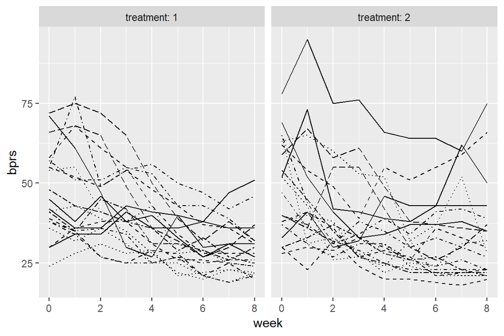

```r
# draw the plot of BPRS with the observed bprs values
ggplot(BPRSL, aes(x = week, y = bprs, linetype = subject)) +
  geom_line() +
  scale_linetype_manual(values = rep(1:10, times=4)) +
  facet_grid(. ~ treatment, labeller = label_both) +
  theme(legend.position = "none") +
  scale_y_continuous(limits = c(min(BPRSL$bprs), max(BPRSL$bprs)))
```

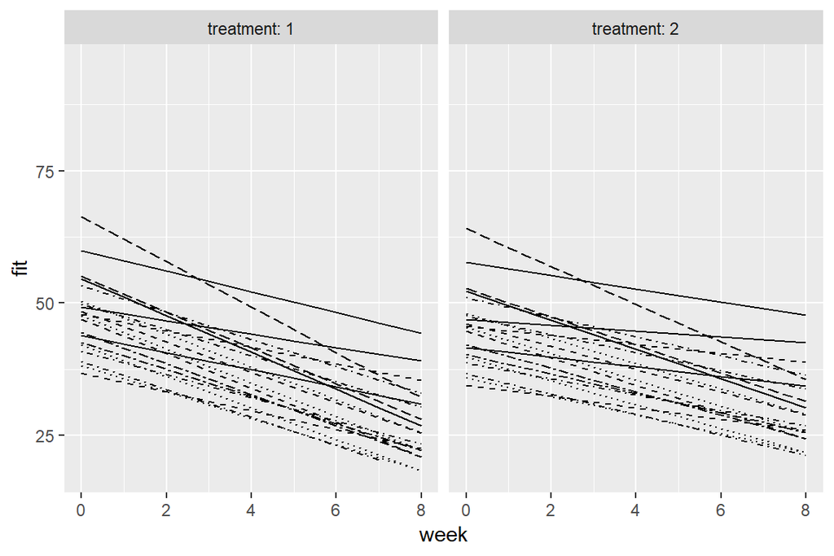

```r
# Create a vector of the fitted values
Fitted <- fitted(BPRS_ref2)

# Create a new column fitted to BPRSL
 BPRSL <- mutate(BPRSL, fit = Fitted)

# draw the plot of BPRS with the Fitted values of bprs
ggplot(BPRSL, aes(x = week, y = fit, linetype = subject)) +
  geom_line() +
  scale_linetype_manual(values = rep(1:10, times=4)) +
  facet_grid(. ~ treatment, labeller = label_both) +
  theme(legend.position = "none") +
  scale_y_continuous(limits = c(min(BPRSL$bprs), max(BPRSL$bprs)))
```